# Shuo-Jen, Chang’s website

## About me

> Summary

Born in April, 1997

Taipei, Taiwan, andrew90524@gmail.com

Currently fourth year in college, economic major. Excelling at data mining & data analysis.  
Highly experienced in tackling commercial problems and predictive tasks

Ranked 223th out of 91104 active users and got Master-tier in the biggest global data science community - Kaggle.

Kaggle profile : https://www.kaggle.com/andrew60909

> Education
- *Taipei Municipal Jianguo High School* < 2012/9 - 2015/6 >
- *Soochow university*, **B.A. Economic** < 2015/9 - now >

> Award

[figure not shown]

**Home Credit Default Risk - 2nd / 7198**

“Home Credit strives to broaden financial inclusion for the unbanked population by providing a positive and safe borrowing experience. In order to make sure this underserved population has a positive loan experience.

Now, they’re challenging us to help them unlock the full potential of their data. Doing so will ensure that clients capable of repayment are not rejected and that loans are given with a principal, maturity, and repayment calendar that will empower their clients to be successful."

https://www.kaggle.com/c/home-credit-default-risk/leaderboard - Team name : “**ikiri_DS**”

[figure not shown]

**Avito Demand Prediction Challenge - 7th / 1873**

“Avito, Russia’s largest classified advertisements website, is deeply familiar with this problem. Sellers on their platform sometimes feel frustrated with both too little demand (indicating something is wrong with the product or the product listing) or too much demand (indicating a hot item with a good description was underpriced).

Now, they are challenging you to predict demand for an online advertisement based on its full description (title, description, images, etc.), its context (geographically where it was posted, similar ads already posted) and historical demand for similar ads in similar contexts. With this information, Avito can inform sellers on how to best optimize their listing and provide some indication of how much interest they should realistically expect to receive."

https://www.kaggle.com/c/avito-demand-prediction/leaderboard - Team name : “**Light in June**”

[figure not shown]

**Recruit Restaurant Visitor Forecasting - 46th / 2158**

“One common predicament is that restaurants need to know how many customers to expect each day to effectively purchase ingredients and schedule staff members. This forecast isn’t easy to make because many unpredictable factors affect restaurant attendance, like weather and local competition. It’s even harder for newer restaurants with little historical data.

In this competition, Recruit Holdings is challenging you to use reservation and visitation data to predict the total number of visitors to a restaurant for future dates. This information will help restaurants be much more efficient and allow them to focus on creating an enjoyable dining experience for their customers."

https://www.kaggle.com/c/recruit-restaurant-visitor-forecasting/leaderboard - as solo

[figure not shown]

**Santander Value Prediction Challenge - 113th / 4484**

“Santander Group aims to go a step beyond recognizing that there is a need to provide a customer a financial service and intends to determine the amount or value of the customer’s transaction. This means anticipating customer needs in a more concrete, but also simple and personal way. With so many choices for financial services, this need is greater now than ever before.

In this competition, Santander Group is asking us to help them identify the value of transactions for each potential customer. This is a first step that Santander needs to nail in order to personalize their services at scale."

https://www.kaggle.com/c/santander-value-prediction-challenge/leaderboard - Team name : “**All your bank are belong to us**”

P.S All the description above are excerpted from kaggle page.

## Solution for DS competition

*I will describe the solution of each of data science competition I joined.*

### Home Credit

**2nd place out of 7198 teams**

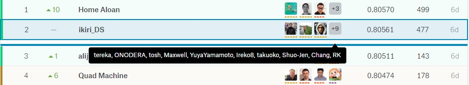

> About our Team

There are 12 members in our team (Team name : **Ikiri_DS**)

- **Kazuki Onodera** : Leader of our team, Data scientist at DeNA ([Linkedin](https://www.linkedin.com/in/kazuki-onodera-a55b8a66/))
- **Branden Murray** : Data scientist at H2O.ai ([Linkedin](https://www.linkedin.com/in/bmurr26/))
- **Daiki Yamamoto** (tereka) : Data scientist at Acroquest technology ([Linkedin](https://www.linkedin.com/in/%E5%A4%A7%E8%BC%9D-%E5%B1%B1%E6%9C%AC-2581b589/))
- **Gilberto Titericz** (Giba) : Lead data scientist in Ople.ai ([Linkedin](https://www.linkedin.com/in/gilberto-titericz-6601357/))
- **Ireko8** : Student at Univ of Tokyo
- **Ryuichi Kano** (RK) : Data scientist at DeNA
- **Shuo-Jen, Chang** (Angus) : Student at Soochow university
- **Tatsumi Okoshi** (takuoko) : Director at kysmo.tech
- **Tam T. Nguyen** : Postdoctoral Research Fellow at Ryerson University ([Linkedin](https://www.linkedin.com/in/nthanhtam/))
- **Tosh** : ?_?
- **Yuji Hiramatsu** (Maxwell) : Actuary at AXA Life Japan, Visiting Researcher at Univ of Tokyo ([Linkedin](https://www.linkedin.com/in/yuuji-hiramatsu-78a669112/))
- **Yuya Yamamoto** : Data scientist at Datarobot ([Linkedin](https://www.linkedin.com/in/yuya-yamamoto-a47a50123/))

> Summary

[figure not shown]

This is our model pipeline, picture was made by Maxwell.

For the detail of solution, please check our post on kaggle ! [Solution](https://www.kaggle.com/c/home-credit-default-risk/discussion/64722)

### Avito

**7th place out of 1873 teams**

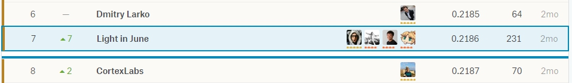

> About our Team

There are 4 members in our team (Team name : **Light in June**)

- **Shuo-Jen, Chang** (Angus) : Leader of the team, Student at Soochow university
- **Branden Murray** : Data scientist at H2O.ai ([Linkedin](https://www.linkedin.com/in/bmurr26/))
- **Tatsumi Okoshi** (takuoko) : Director at kysmo.tech
- **Yusaku Sako** : Director of Engineering at Hortonworks ([Linkedin](https://www.linkedin.com/in/yusaku-sako-b793/))

> Summary

In this competition, Our mission was to predict demand(deal_probability) for an online advertisement based on its full description (title, description, images, etc.), its context (geographically where it was posted, similar ads already posted) and historical demand for similar ads in similar contexts.

#### Evaluation

$$RMSE = \sqrt{\frac{1}{n} \sum_{i=1}^n (y_i - \hat{y}_i)^2 },$$

#### Date description

- train.csv & test.csv : train & test data.
- train_active.csv & test_active.csv : Supplemental data from ads that were displayed during the same period as train & test data.
- periods_train.csv & periods_test.csv : Supplemental data showing the dates when the ads from traint_active & test_active data were activated and when they where displayed.
- train_jpg.zip & test_jpg.zip : Images from the ads in train & test data.

> Takuoko and Angus’s solution

Takuoko and I merged on 10 days before merger deadline.

#### Feature Enginnering

- different word n-gram and char n-gram then doing TF-IDF(or not).
- join text into one field : {description, title, category_name} & {param_1,param_2,param_3,title}.
- [text stats features](https://www.kaggle.com/sudalairajkumar/simple-feature-engg-notebook-spooky-author)
- [Some aggregated features from public kernel](https://www.kaggle.com/bminixhofer/aggregated-features-lightgbm)
- [image features : mean, whiteness, dullness of RGB](https://www.kaggle.com/shivamb/ideas-for-image-features-and-image-quality)
- Aggregated feature(mean/max/min/sd) that group up by different categorical feature.
- n-way interactions between categorical features (n up to 4)
- Applying PCA / TSVD to OHE categorical features
- count encoding on categorical features
- [likelihood encoding](https://github.com/diefimov/santander_2016) with following formula :
  $$LL = \frac {30 \cdot \bar{y} + \sum_{i \in G} y_i} {30 + |G|}$$
  Where $G$ is the set of indices for the training examples with constant value of categorical features. $|G|$ is the size of group $G$, $\bar{y}$ is the global mean of all target value. the number “30” here is constant value. You can change it to any number you want if reasonable.
  I only encode the categorical features with low/medium cardinality and binning features, and apply label encoding to high-cardinality one (city).
- quantile or histogram-based binning.
- In order to apply the likelihood encoding to “item-seq-number”, I created another features same as “item-seq-number” but transformed the number greater than 300, than apply different encoding on it.

| number | transformed |
| --- | --- |
| 350 >= x > 300 | 301 |
| 450 >= x > 350 | 302 |
| 600 >= x > 450 | 303 |
| 800 >= x > 600 | 304 |
| 1200 >= x > 800 | 305 |
| 2000 >= x > 1200 | 306 |
| 4000 >= x > 2000 | 307 |
| 10000 >= x > 2000 | 308 |
| x > 10000 | 309 |

#### The thing that didn’t work this time

- nunique feature 3-way interactions
- Ridge/glm trick
- Applying tsvd on tf-idf text feature or VGG16 features
- Ohe-hot encoding on categorical features
- Applying GaussianRandomProjection / FastICA / LDA / SparseRandomProjection on OHE
- [fuzzywuzzy features](https://github.com/seatgeek/fuzzywuzzy)

#### Modeling

- Tree based model : LGBM, XGB  
  Basically we used Bayesian for our tuning. And there is something special in our setting, In LGBM, Takuoko set 0.1 to feature_fraction and low colsample_byleve in XGB. We achieve great success by performing bagging with different seed. We can get huge improvement by 5,10 seed avg with LGBM by this approach.  
  We also used objective=poisson. It needs more time to converge and its performance is not so good, but it gave us some extra boost when we doing stacking.
- Neural Network :  
  We constructed a lot of NN with different stuff like GRU, Conv1D, Conv2D based on this [public kernel](https://www.kaggle.com/shanth84/rnn-detailed-explanation-0-2246).  
  We also made a simple multi-layer process since its score is pretty bad but good for stacking. Until end, We still can’t let our NN model beat the benchmark on public kernel. even with Batch-Normalization and fine-tuned Dropout. And that’s pretty frustrated for both of us.
- Ridge, drop0 model  
  Ridge and [drop0 model](https://www.kaggle.com/c/allstate-claims-severity/discussion/26416) also were not good solo, but both of them improved our stacking score.  
  Drop 0 model was inspired by the link above. We just dropped target=0 and train a LGBM.

> Branden and Yusaku’s Solution

Branden and Yusaku were working together before merging with us. Branden and Yusaku used the same 5-folds based on a random split to train their level 0 models.

“I trained 10 level-0 LGBM models that utilized image features. My models were largely based on the kernel https://www.kaggle.com/him4318/avito-lightgbm-with-ridge-feature-v-2-0/code (v14) with some tweaks and addition of CNN image features. To add CNN features, the images were first resized to 224x224 and activations from the layer right before classification layers were extracted and average pooled. The models were initialized with pre-trained weights from ImageNet. The follow image features were used in the final models, though other CNN models were experimented with and did not work as well or were not usable due to memory constraints:

- VGG16 (512x7x7) || Average pool (512x1x1) - Improved 0.0008 LB
- Densenet121 (1024x7x7) || Average pool (1024x1x1) - Improved 0.0012 LB

Both average and max pool were tried, but average pool gave better CV/LB, so I ended up just using average pooled features in the final models. It would have been interesting to try lower level image features extracted from the CNN models (to better capture qualities such as image focus, fuzziness, graininess), but did not get around to it.

To encourage diversity and reduce correlations for the trained models, some were trained by removing features that were deemed important by LGBM, such as “image_top_1”, “city”, etc.

For text features, TFIDF of bigrams were used, unmodified from the original base kernel. I also experimented with adding text features based on gensim’s doc2vec but did not help. I did not try FastText, but I probably should have based on favorable results reported by other teams.

My models’ predictions ended up having relatively low correlations with Branden’s models despite both of us using LGBM; combining my models with Branden’s gave a pretty big boost." - From Yusaku Sako

> Final Ensembling

Our final solution was large stacking that involved 64 models in total. It’s quite similar to the post that was posted by KazAnova on the [kaggle blog](http://blog.kaggle.com/2017/06/15/stacking-made-easy-an-introduction-to-stacknet-by-competitions-grandmaster-marios-michailidis-kazanova/) before. And after we completed building models, We grouped all the level-0 model into 4 group in order to gain some diversity :

- All models
- Branden and Takuoko-Angus models
- Takuoko-Angus and Yusaku models
- Yusaku and Branden models

We used the following models for our stacking (level-1 & level-2) : {XGB gblinear, LGBM, Ridge, Extra Trees, simple NN}. Finally we got 20 level-1 models & 5 level-2 model in consequence. than we just use a simple ridge for level-3 stacking (but excluded the meta-features which had negative weight in ridge, than rerun, until there is no negative weight appeared). It was one of our last submission, it scored 0.2148 on public LB (private 0.2186 / CV 0.208749).

In another submission, I just applied the optim() function in R with BFGS solver on level-1 meta-features to find the best weight to blend, with following formula : x1 * model1 + x2 * model2 + …… +x20 * model20 + x21. It worked almost same well as our level-3 stacking. It scored 0.2148 on public LB(private 0.2186 / CV 0.2087724). Actually two sub are quite same.

### Recruit Restaurant

**46th place out of 2158 teams (TOP 3%) - as solo**

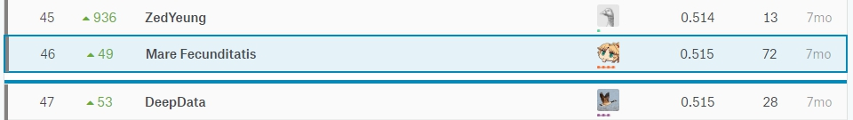

> Summary

In this competition, My mission was to use the visitation and reservation data from 2016/1/1 to 2017/4/22 to forecast the total number of visitors to the restaurant in the future (4/23 to 5/31). First, For my modeling, I used gradient boost machine (LightGBM[1]) which was opensourced by Microsoft and decided to treat the problem as a regression problem. Second, For my feature engineering, I started off from the public Kernal which was wrote by **Konrad Banachewicz**[2], and then I created some new different features. My principle was to extract the past imformation of the dataset as much as I can. Basically I could categorize my new-constructed features into 3 different type:

- measures of centrality and measures of spread of target value (vistors) in different time window
- time features
- other imformation

As to my validation strategy. I just simply used the holdout validation set which contained last 39-days data(same length with the test set). And of course, not to use any information that was from the holdout set in order to avoid the leakage. The information leakage may invalid your strategy.

#### Data description

- air_reserve.csv : This file contains reservations made in the air system.
- air_store_info.csv : This file contains information about select restaurants.
- air_visit_data.csv : This file contains historical visit data for the restaurants.
- date_info.csv : This file gives basic information about the calendar dates in the dataset.

#### Evaluation

$$RMSLE = \sqrt{\frac{1}{n} \sum_{i=1}^n (\log(p_i + 1) - \log(a_i+1))^2 },$$

$n$ is the total number of observations  
$p_i$ is your prediction of visitors  
$a_i$ is the actual number of visitors  
$log(x)$ is the natural logarithm of $x$

> Feature Engineering

I will describe my strategy detaily in this part, including my thought, and how I selected or measured the performance of the features I constructed.

#### General approach (Pre-pocessing)

I made a quick-examimed to the dataset and performed exploratory data analysis(EDA) for the dataset. Fortunately there are only fews of missing values here, I just simply impute them with 0 which was selected by my validation set(I also tried -1, -999 etc.). Then I applied log-transformed to the target values(vistors).

#### Measures of centrality and spread features

First, When it comes to forecasting problem, I knew that one of the key points was to find the seasonality. After doing some slight EDA, I could easliy find out that there was a extremely strong weekly seasonality in this task. So, I constucted a lot of statistical features based on different time window. To summarize them, I applied measures of centrality and spread:

- centrality : mean / median / harmonic mean / exponential weighted average / sum(given exponential weight) of the visitors for past 1 year / half year / 3 months / 1 month / 14 days / 7 days (grouped by {weekdays, store_id} or only grouped by {store_id})
- spread : standard deviation / skewness / kurtosis / maximum / minimum of the visitors for past 1 year / half year / 3 months / 1 month / 14 days / 7 days (grouped by {weekdays, store_id} or only grouped by {store_id})

I also tried the same approach to the target value before log transformed, but none of them gave me the positive feedback.

#### Time features

In order to extracting the “day-status” information, I had made some time features to show the current info of the day. e.g. day of week, month of year, week of year. and not surprisingly. My model could easily capture the trend and achieved a big improvement with some of them.

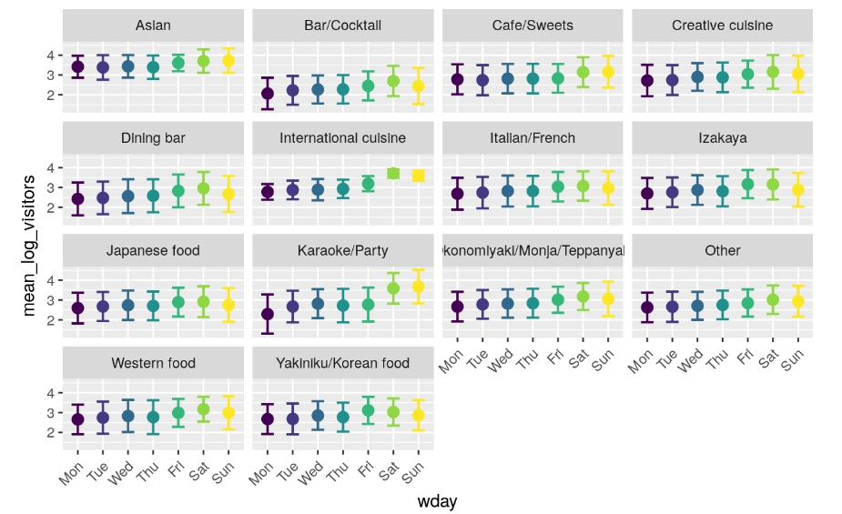

Also, I assumed that the numbers of vistors will be affected by the status of yesterday and tomorrow. For example, If tomorrow is holidays or weekends, people will be more willing to visit the restaurant today. In other word, people’s intension of visiting is partly determined by “Do I need to work tomorrow”. So, I constructed a feature to express the sequence status of past day, today and tomorrow, then treat it as a categorical ones, For example, the holidays and weekends was encoded as 1, normal days was encoded as 0, So if today is friday, and yesterday is not holidays, then it would be like 0-0-1. In summary, this new categorial features would have 8 levels and each of them stands for different situation. This one also give me a little boost.

#### Other information

To deal with the categorical features. I have applied different kind of encoding way like one-hot encoding, count encoding or some other encoding way, and based on the performance on CV, the likelihood encoding[4] was the best.

About likelihood encoding. We can think of it as a different kind of target mean encodng with following formula:

$$LL = \frac {30 \cdot \bar{y} + \sum_{i \in G} y_i} {30 + |G|}$$
Where $G$ is the set of indices for the training examples with constant value of categorical features. $|G|$ is the size of group $G$, $\bar{y}$ is the global mean of all target value. the number “30” here is constant value. We can manupulate the strength of smoothing(using global mean).

> Modeling

For my final submission, after adding above engineered features, I made two different model. One with centrality and spread features that were grouped by {store_id, weekdays}, another model with the one grouped only by {store_id}. These two model have generated great diversity for me. To ensemble them, I just applied the optim() function in R with Nelder-Mead solver on my holdout-set to find the best weight to blend, with following formula : “x1 * model1 + x2 * model2 + x3”. And finally I got 46th in this competition.

> Reference
- [1] https://github.com/Microsoft/LightGBM
- [2] https://www.kaggle.com/konradb/lightgbm-with-fe-and-validation
- [3] https://www.kaggle.com/headsortails/be-my-guest-recruit-restaurant-eda
- [4] https://github.com/diefimov/santander_2016